# Rep_Researc_Proj_1

2024-04-07

# Reproducible Research Project 1

First we load our packages.

Then the first step in the analysis is to read in our data and prepare it for analysis. The only transformation applied was transforming the date column into the correct format.

```r
library(tidyverse)
library(zoo)
act0 <- read.csv("./project1/activity.csv")
act1 <- transform(act0, date = ymd(act0$date))
```

## Total Steps per Day

The below code first groups our data by each date then graphs it in a histogram.

The histogram displays the total number of steps taken per day across all days in the data set.

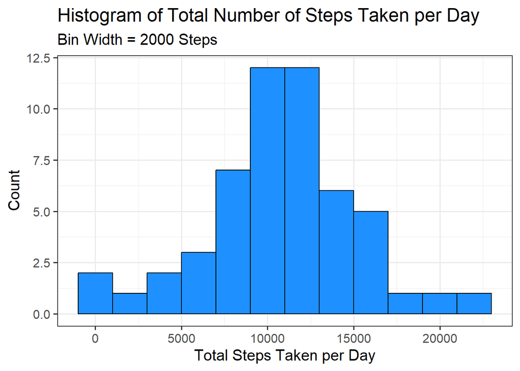

```r
steps <- act1 %>%
  group_by(date) %>%
  summarise(total_steps = sum(steps))

ggplot(data = steps) +
  geom_histogram(aes(x = total_steps), binwidth = 2000,
                 col = "black", fill = "dodgerblue") +
  theme_bw(base_size = 15) +
  labs(title = "Histogram of Total Number of Steps Taken per Day",
       x = "Total Steps Taken per Day", y = "Count",
       subtitle = "Bin Width = 2000 Steps")
```

```r
mean_steps <- as.integer(mean(steps$total_steps, na.rm = TRUE))
median_steps <- median(steps$total_steps, na.rm = TRUE)
```

The mean steps taken per day is 10766 and the median steps taken per day is 10765.

## Activity Pattern

The below code groups our data by each 5-minute interval recorded daily. We then graph the **average daily steps taken per day** *across* **each of the 5-minute intervals** recorded daily. This is shown in the below time series plot.

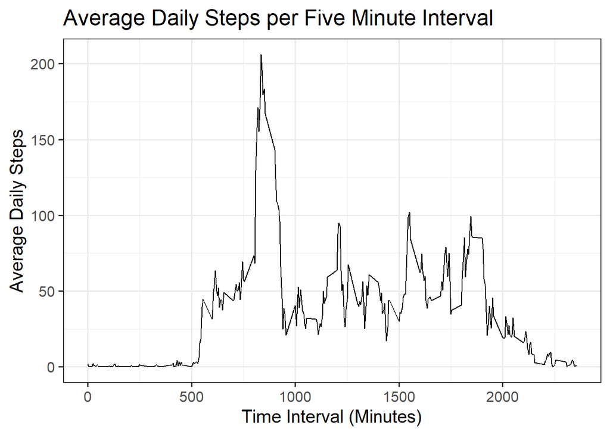

```r
pattern <- act1 %>%
  group_by(interval) %>%
  summarise(steps_p = mean(steps, na.rm = TRUE))

ggplot(data = pattern) +
  geom_line(aes(x = interval, y = steps_p), lwd = 0.5) +
  theme_bw(base_size = 15) +
  labs(title = "Average Daily Steps per Five Minute Interval",
       x = "Time Interval (Minutes)", y = "Average Daily Steps")
```

```r
max <- max(pattern$steps_p)
max_values <- filter(pattern, steps_p == max)
max_int <- as.numeric(max_values[,1])
```

The 5-minute interval, which on average, across all days in the data contains the maximum number of steps is 835.

## Missing Values

```r
nas <- sum(is.na(act1$steps))
```

The total number of NAs within our data set is 2304.

The below code replaces the NA values in the data set with the mean value of that corresponding 5-minute interval across **all days**.

This data is the plotted in another histogram displaying the total number of steps taken per day with the filled-in data.

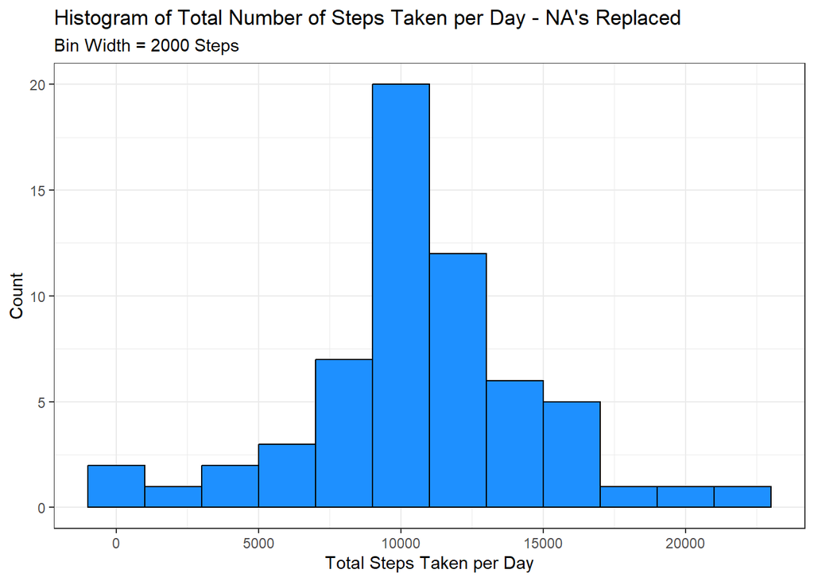

```r
act2 <- act1 %>%
  group_by(interval) %>%
  mutate(across(where(is.numeric), na.aggregate)) %>%
  ungroup

steps2 <- act2 %>%
  group_by(date) %>%
  summarise(total_steps = sum(steps))

ggplot(data = steps2) +
  geom_histogram(aes(x = total_steps), binwidth = 2000,
                 col = "black", fill = "dodgerblue") +
  theme_bw(base_size = 11) +
  labs(title = "Histogram of Total Number of Steps Taken per Day - NA's Replaced",
       x = "Total Steps Taken per Day", y = "Count",
       subtitle = "Bin Width = 2000 Steps")
```

```r
mean_steps2 <- as.integer(mean(steps2$total_steps, na.rm = TRUE))
median_steps2 <- as.integer(median(steps2$total_steps, na.rm = TRUE))
```

The mean and median of steps taken were then recalculated based on the **filled in data**. The updated mean steps taken per day is 10766 and the updated median steps taken per day is 10766. These values are **almost identical** to the previously calculated mean and median.

## Weekdays vs Weekends

Based on the **filled in** data set, we add two columns to our data. The first one assigns a *day of the week* to each observation and the second classfies each day as either a *weekday* or *weekend*.

A plot is then created showing the average number of steps taken per 5-minute interval, comparing weekdays to weekends.

```r
days <- weekdays(act2$date)

weekdays_fac <- factor(days, levels = c("Monday", "Tuesday", "Wednesday",
                                   "Thursday", "Friday", "Saturday", "Sunday"),
                 labels = c("Weekday", "Weekday", "Weekday", "Weekday", "Weekday",
                            "Weekend", "Weekend"))
act3 <- cbind(act2, days, weekdays_fac)
colnames(act3) <- c("steps", "date", "interval", "days", "weekdays")

pattern2 <- act3 %>%
  group_by(interval, weekdays) %>%
  summarise(steps_p = mean(steps))
```

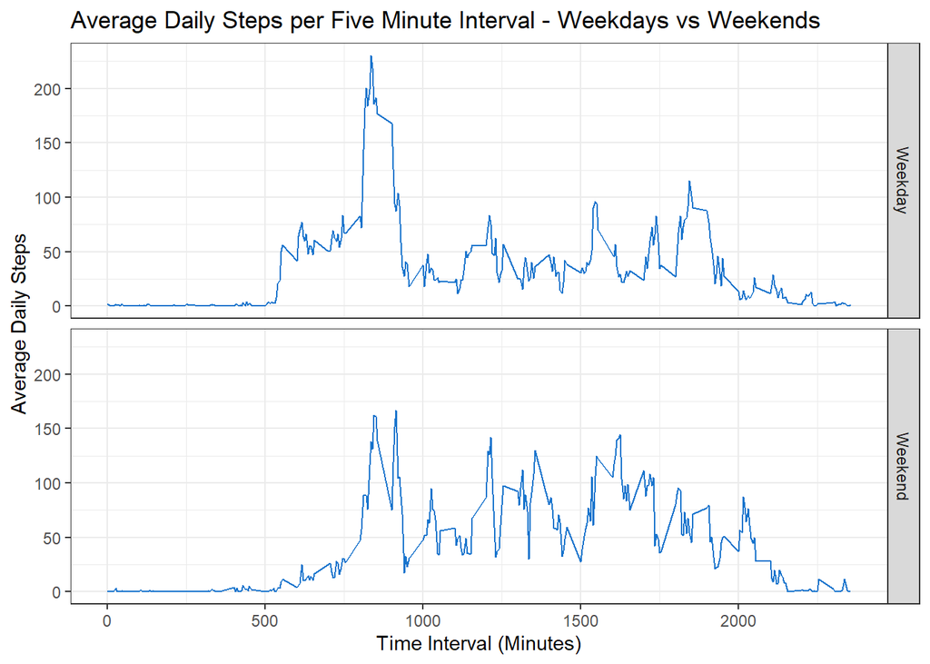

```r
ggplot(data = pattern2) +
  geom_line(aes(x = interval, y = steps_p), col = "dodgerblue3") +
  facet_grid(rows = vars(weekdays)) +
  theme_bw(base_size = 11) +
  labs(title = "Average Daily Steps per Five Minute Interval - Weekdays vs Weekends",
       x = "Time Interval (Minutes)", y = "Average Daily Steps")
```

Thank you for reading this knitr file! That concludes my analysis for this assignment.